# Credit Card fraud detection

Aditya Lakkad

22/09/2020

## Loading the Dataset and claening the Data

importing the data set from respective folder.

```r
credit_card <- read.csv("E:\\SEM-5\\DSM\\Project\\creditcard.csv")
```

viewing data set

```r
print(str(credit_card))
```

```
## 'data.frame':    284807 obs. of  31 variables:
##  $ Time  : num  0 0 1 1 2 2 4 7 7 9 ...
##  $ V1    : num  -1.36 1.192 -1.358 -0.966 -1.158 ...
##  $ V2    : num  -0.0728 0.2662 -1.3402 -0.1852 0.8777 ...
##  $ V3    : num  2.536 0.166 1.773 1.793 1.549 ...
##  $ V4    : num  1.378 0.448 0.38 -0.863 0.403 ...
##  $ V5    : num  -0.3383 0.06 -0.5032 -0.0103 -0.4072 ...
##  $ V6    : num  0.4624 -0.0824 1.8005 1.2472 0.0959 ...
##  $ V7    : num  0.2396 -0.0788 0.7915 0.2376 0.5929 ...
##  $ V8    : num  0.0987 0.0851 0.2477 0.3774 -0.2705 ...
##  $ V9    : num  0.364 -0.255 -1.515 -1.387 0.818 ...
##  $ V10   : num  0.0908 -0.167 0.2076 -0.055 0.7531 ...
##  $ V11   : num  -0.552 1.613 0.625 -0.226 -0.823 ...
##  $ V12   : num  -0.6178 1.0652 0.0661 0.1782 0.5382 ...
##  $ V13   : num  -0.991 0.489 0.717 0.508 1.346 ...
```

[output cut: 18 more lines]

converting Class into factor, levels=(0,1) and getting summary of the data

```r
credit_card$Class <- factor(credit_card$Class, levels=c(0,1))
print(summary(credit_card))
```

```
##       Time              V1                  V2                  V3
##  Min.   :     0   Min.   :-56.40751   Min.   :-72.71573   Min.   :-48.3256
##  1st Qu.: 54202   1st Qu.: -0.92037   1st Qu.: -0.59855   1st Qu.: -0.8904
##  Median : 84692   Median :  0.01811   Median :  0.06549   Median :  0.1799
##  Mean   : 94814   Mean   :  0.00000   Mean   :  0.00000   Mean   :  0.0000
##  3rd Qu.:139321   3rd Qu.:  1.31564   3rd Qu.:  0.80372   3rd Qu.:  1.0272
##  Max.   :172792   Max.   :  2.45493   Max.   : 22.05773   Max.   :  9.3826
##        V4                 V5                   V6                 V7
##  Min.   :-5.68317   Min.   :-113.74331   Min.   :-26.1605   Min.   :-43.5572
##  1st Qu.:-0.84864   1st Qu.:  -0.69160   1st Qu.: -0.7683   1st Qu.: -0.5541
##  Median :-0.01985   Median :  -0.05434   Median : -0.2742   Median :  0.0401
##  Mean   : 0.00000   Mean   :   0.00000   Mean   :  0.0000   Mean   :  0.0000
##  3rd Qu.: 0.74334   3rd Qu.:   0.61193   3rd Qu.:  0.3986   3rd Qu.:  0.5704
##  Max.   :16.87534   Max.   :  34.80167   Max.   : 73.3016   Max.   :120.5895
##        V8                  V9                 V10                 V11
##  Min.   :-73.21672   Min.   :-13.43407   Min.   :-24.58826   Min.   :-4.79747
##  1st Qu.: -0.20863   1st Qu.: -0.64310   1st Qu.: -0.53543   1st Qu.:-0.76249
##  Median :  0.02236   Median : -0.05143   Median : -0.09292   Median :-0.03276
##  Mean   :  0.00000   Mean   :  0.00000   Mean   :  0.00000   Mean   : 0.00000
##  3rd Qu.:  0.32735   3rd Qu.:  0.59714   3rd Qu.:  0.45392   3rd Qu.: 0.73959
##  Max.   : 20.00721   Max.   : 15.59500   Max.   : 23.74514   Max.   :12.01891
##       V12                V13                V14                V15
##  Min.   :-18.6837   Min.   :-5.79188   Min.   :-19.2143   Min.   :-4.49894
##  1st Qu.: -0.4056   1st Qu.:-0.64854   1st Qu.: -0.4256   1st Qu.:-0.58288
##  Median :  0.1400   Median :-0.01357   Median :  0.0506   Median : 0.04807
##  Mean   :  0.0000   Mean   : 0.00000   Mean   :  0.0000   Mean   : 0.00000
##  3rd Qu.:  0.6182   3rd Qu.: 0.66251   3rd Qu.:  0.4931   3rd Qu.: 0.64882
##  Max.   :  7.8484   Max.   : 7.12688   Max.   : 10.5268   Max.   : 8.87774
##       V16                 V17                 V18
##  Min.   :-14.12985   Min.   :-25.16280   Min.   :-9.498746
##  1st Qu.: -0.46804   1st Qu.: -0.48375   1st Qu.:-0.498850
##  Median :  0.06641   Median : -0.06568   Median :-0.003636
##  Mean   :  0.00000   Mean   :  0.00000   Mean   : 0.000000
##  3rd Qu.:  0.52330   3rd Qu.:  0.39968   3rd Qu.: 0.500807
##  Max.   : 17.31511   Max.   :  9.25353   Max.   : 5.041069
##       V19                 V20                 V21
##  Min.   :-7.213527   Min.   :-54.49772   Min.   :-34.83038
##  1st Qu.:-0.456299   1st Qu.: -0.21172   1st Qu.: -0.22839
##  Median : 0.003735   Median : -0.06248   Median : -0.02945
##  Mean   : 0.000000   Mean   :  0.00000   Mean   :  0.00000
```

[output cut: 8 more lines]

```
##  Max.   : 10.503090   Max.   : 22.52841   Max.   : 4.58455
##       V25                 V26                V27
##  Min.   :-10.29540   Min.   :-2.60455   Min.   :-22.565679
##  1st Qu.: -0.31715   1st Qu.:-0.32698   1st Qu.: -0.070840
##  Median :  0.01659   Median :-0.05214   Median :  0.001342
##  Mean   :  0.00000   Mean   : 0.00000   Mean   :  0.000000
##  3rd Qu.:  0.35072   3rd Qu.: 0.24095   3rd Qu.:  0.091045
##  Max.   :  7.51959   Max.   : 3.51735   Max.   : 31.612198
##       V28                Amount         Class
##  Min.   :-15.43008   Min.   :    0.00   0:284315
##  1st Qu.: -0.05296   1st Qu.:    5.60   1:   492
##  Median :  0.01124   Median :   22.00
##  Mean   :  0.00000   Mean   :   88.35
##  3rd Qu.:  0.07828   3rd Qu.:   77.17
##  Max.   : 33.84781   Max.   :25691.16
```

Count the missing Values

```r
print(sum(is.na(credit_card)))
```

```
## [1] 0
```

So here data is clean and ready for the further process

## Exploring the data

Get the distribution of fraud and legit transaction in deta set

```r
print(table(credit_card$Class))
```

```
##
##      0      1
## 284315    492
```

finding the probability of the data of fraud and legit transection

```r
print(prop.table(table(credit_card$Class)))
```

```
##
##           0           1
## 0.998272514 0.001727486
```

plotting a piechart of creditcard transaction

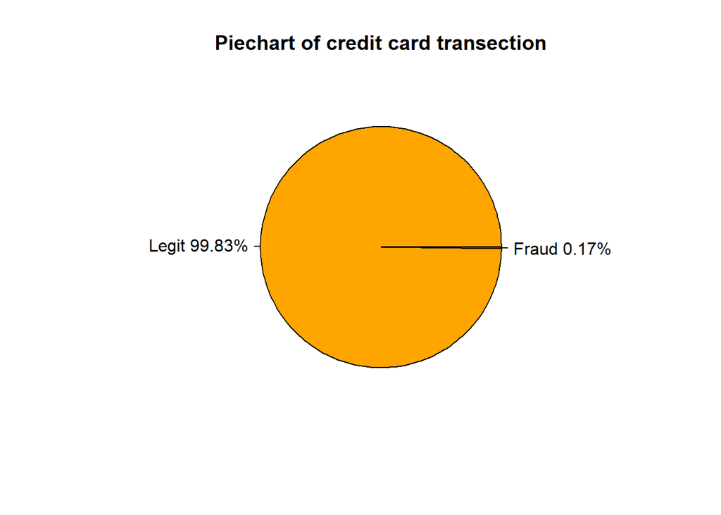

```r
labels <- c("Legit","Fraud")
labels <- paste(labels, round(100*prop.table(table(credit_card$Class)), 2))
labels <- paste0(labels, "%")
pie(table(credit_card$Class), labels, col = c("orange","Red"), main="Piechart of credit card transection")
```

## Note :

#### Now after seeing the data I have noticed that there are major difference between amount of data, We have a lot more legit transaction data then the fraud transaction data. As solution for this we will create synthetic samples with techniques like random over sampling, randome under sampling , SMOTE etc. But first lets look at no model prediction

## No model prediction

Here I am predicting data without any model on Class factor and then based on that I am getting a confusion matrix. For that I am using “caret” module.

```r
#No model predictions
predictions <- rep.int(0, nrow(credit_card))
predictions<- factor(predictions, levels = c(0,1))
library(caret)
confusionMatrix(data=predictions, reference = credit_card$Class)
```

```
## Confusion Matrix and Statistics
##
##           Reference
## Prediction      0      1
##          0 284315    492
##          1      0      0
##
##                Accuracy : 0.9983
##                  95% CI : (0.9981, 0.9984)
##     No Information Rate : 0.9983
##     P-Value [Acc > NIR] : 0.512
##
##                   Kappa : 0
##
##  Mcnemar's Test P-Value : <2e-16
##
##             Sensitivity : 1.0000
##             Specificity : 0.0000
##          Pos Pred Value : 0.9983
##          Neg Pred Value :    NaN
##              Prevalence : 0.9983
##          Detection Rate : 0.9983
##    Detection Prevalence : 1.0000
##       Balanced Accuracy : 0.5000
##
##        'Positive' Class : 0
##
```

```r
library(dplyr)
set.seed(1)
credit_card <- credit_card %>% sample_frac(0.1)

table(credit_card$Class)
```

```
##
##     0     1
## 28437    44
```

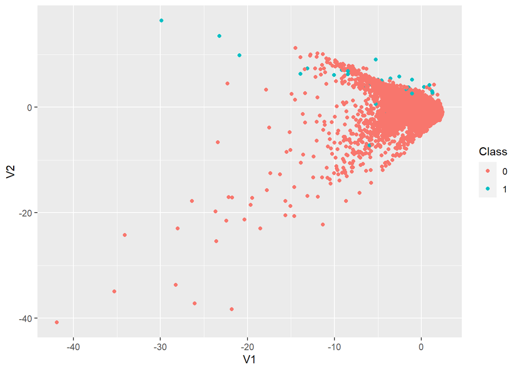

```r
library(ggplot2)

ggplot(data = credit_card, aes(x = V1, y = V2, col = Class)) +
  geom_point()
```

## Training and test sets for our model

Creating training and Test sets for fraud Detection Model using library caTools. Our training data contains 80% of total data and test data contains 20% of total data.

```r
library(caTools)

set.seed(123)

data_sample = sample.split(credit_card$Class, SplitRatio = 0.80)

train_data = subset(credit_card, data_sample==TRUE)

test_data = subset(credit_card,data_sample==FALSE)

print(dim(train_data))
```

```
## [1] 22785    31
```

```r
print(dim(test_data))
```

```
## [1] 5696   31
```

## Creating synthetic samples of training data

## Note:

#### I have used ROS(random over sampling), RUS(Random under sampling), ROS and RUS both and SMOTE. From all this SMOTE was the best at giving high quality data. So I am mentioning that steps as I have used that data to train my model

Using SMOTE to balance the dataset

```r
library(smotefamily)
table(train_data$Class)
```

```
##
##     0     1
## 22750    35
```

set the number of fraud and legitimate cases and the desired percentage of legitimate cases

```r
n0 <- 22750
n1 <- 35
r0 <- 0.6
```

Calculate number of How many times we have to run the SMOTE

```r
ntimes <- ((1-r0)/r0)*(n0/n1)-1
```

Applying SMOTE

```r
smote_output = SMOTE(X = train_data[,-c(1,31)],
                     target = train_data$Class,
                     K = 5,
                     dup_size = ntimes)
credit_smote <- smote_output$data
```

Renaming column 30 to “Class”

```r
colnames(credit_smote)[30] <- "Class"
```

printing probability distribution to check whether we got desired data or not

```r
print(prop.table(table(credit_smote$Class)))
```

```
##
##         0         1
## 0.6001847 0.3998153
```

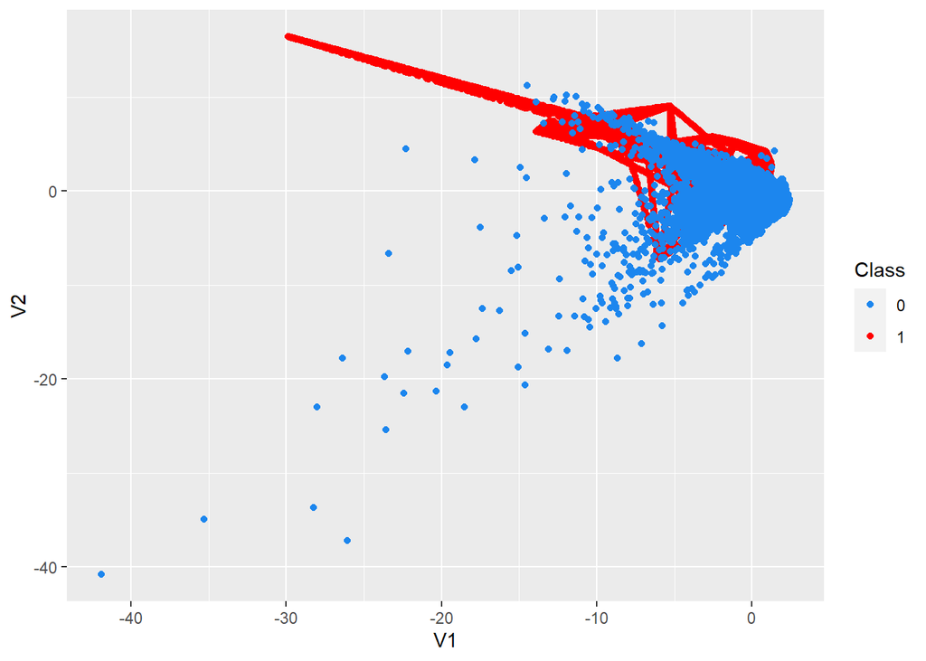

```r
ggplot(credit_smote, aes(x = V1, y=V2, color = Class)) +
  geom_point() +
  scale_color_manual(values = c('dodgerblue2', 'red'))
```

Class distribution for over sampled dataset using SMOTE

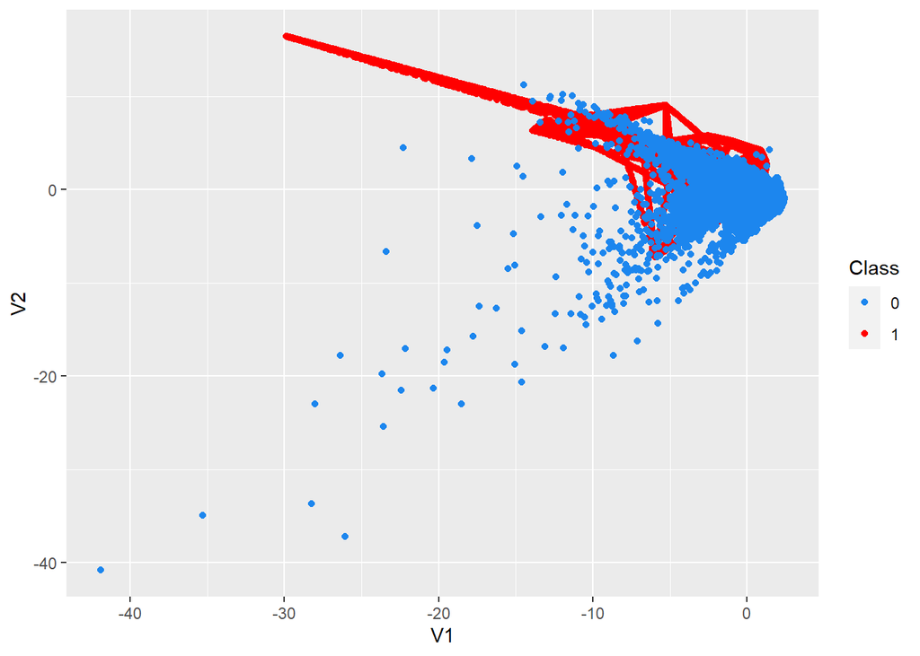

```r
ggplot(credit_smote, aes(x = V1, y=V2, color = Class)) +
  geom_point() +
  scale_color_manual(values = c('dodgerblue2', 'red'))
```

## Decision Tree with trained model

we will use “rpart” and “rpart.plot” module

```r
library(rpart)
library(rpart.plot)
```

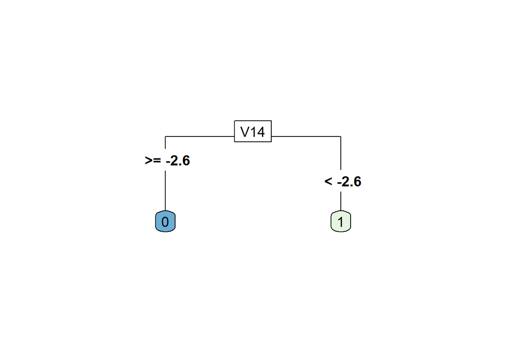

```r
CART_MODEL <- rpart(Class ~ ., credit_smote)
rpart.plot(CART_MODEL, extra = 0, type = 5, tweak = 1.2)
```

predict fraud classes

```r
predicted_val <- predict(CART_MODEL, test_data, type = 'class')
```

```r
confusionMatrix(predicted_val, test_data$Class)
```

```
## Confusion Matrix and Statistics
##
##           Reference
## Prediction    0    1
##          0 5622    2
##          1   65    7
##
##                Accuracy : 0.9882
##                  95% CI : (0.9851, 0.9909)
##     No Information Rate : 0.9984
##     P-Value [Acc > NIR] : 1
##
##                   Kappa : 0.1705
##
##  Mcnemar's Test P-Value : 3.605e-14
##
##             Sensitivity : 0.98857
##             Specificity : 0.77778
##          Pos Pred Value : 0.99964
##          Neg Pred Value : 0.09722
##              Prevalence : 0.99842
##          Detection Rate : 0.98701
##    Detection Prevalence : 0.98736
##       Balanced Accuracy : 0.88317
##
##        'Positive' Class : 0
##
```

```r
predicted_val <- predict(CART_MODEL, credit_card[,-1], type = 'class')
confusionMatrix(predicted_val, credit_card$Class)
```

```
## Confusion Matrix and Statistics
##
##           Reference
## Prediction     0     1
##          0 28141     4
##          1   296    40
##
##                Accuracy : 0.9895
##                  95% CI : (0.9882, 0.9906)
##     No Information Rate : 0.9985
##     P-Value [Acc > NIR] : 1
##
##                   Kappa : 0.2084
##
##  Mcnemar's Test P-Value : <2e-16
##
##             Sensitivity : 0.9896
##             Specificity : 0.9091
##          Pos Pred Value : 0.9999
##          Neg Pred Value : 0.1190
##              Prevalence : 0.9985
##          Detection Rate : 0.9881
##    Detection Prevalence : 0.9882
##       Balanced Accuracy : 0.9493
##
##        'Positive' Class : 0
##
```